# RDA project

JBNU statistics

2021 12 14

## 목적 : 단동 비닐하우스 환기율 및 온습도에 대한 예측모형 구축 및 평가 (반응변수 : 내부기온)

## 사용모형 : Multiple Linear Regression Model v.s Artificial Neural Network Model (ANN)

## 0. 분석방향

- 내부기온을 반응변수로, 외부기온, 외부풍속, 외부일사량, 환기창면적을 독립변수로 하는 선형회귀모형 적합.
- 작물유무에 따라 실험이 수행되었으므로 두 경우에 각각 다른 모형을 적합해보고, 두 데이터세트를 합쳐서 작물유무를 추가 독립변수로 가지는 모형을 또한 적합하여 본다.
- 환기율은 외부기온, 외부풍속, 환기창면적 등에 의해 계산되는 값이다. 이 변수들이 이미 독립변수로 고려되었으므로 환기율은 독립변수에 포함시키지 않는다.
- 고려하는 독립변수들은 모두 어느 정도의 중요도를 가진다고 판단된다. 따라서, 영향력이 큰 변수들을 골라내아 단순화된 모형을 찾는 것이 본 분석의 일차적인 목적은 아닐 수 있다.
- 독립변수들간의 교호작용(혹은 상호작용: interaction effect)이 존재할 수 있다. 하지만 교호작용의 포함은 모형의 해석을 난해하게 만들 수 있다.
- 위 요소들을 종합하여, (1) 가능한 모든 효과를 포함한 모형 (2) 예측성능 혹은 변수선택측도 등의 차원에서 가장 우수한 모형 (3) 모든 독립변수들의 주효과를 포함하되 교호작용은 최소한으로 포함한 모형, 크게 3개의 차원에서 모형을 살펴보고 그 예측성능 및 설명력 등을 비교하여 보겠다.

## 1. Loading data

- 작물있음 데이터에서 외부CO2의 값이 결측치인 경우는 제외하였음.

```r
# setwd("D:/OneDrive - 전북대학교/전북대학교/농림과학원용역/2021")
plantyes <- read.csv("C:/Users/stat/Desktop/작물있음.csv",sep=",",header=T)
plantyes <- plantyes[is.na(plantyes$외부CO2)==FALSE,]
head(plantyes,10)
```

```
##    외부기온 내부기온 내외부기온차 외부상대습도 내부상대습도 내외부상대습도차
## 1      22.9     31.1          8.3         78.7         55.0             23.7
## 2      22.8     29.7          6.9         77.1         58.7             18.4
## 3      23.3     29.7          6.4         75.5         58.4             17.1
## 4      23.6     29.8          6.2         72.9         57.8             15.1
## 5      24.0     30.0          6.0         71.2         56.4             14.8
## 6      25.1     33.3          8.1         66.6         49.6             17.0
## 7      25.9     35.6          9.7         66.0         43.6             22.4
## 8      25.0     34.0          8.9         68.0         44.9             23.1
## 9      25.9     33.7          7.8         65.6         46.4             19.2
## 10     26.8     35.9          9.1         61.8         44.1             17.7
##    외부CO2 내부CO2 내외부CO2차 외부풍속 외부일사량 환기율 환기창면적 작물유무
## 1    469.5   462.0         7.5    1.398      372.7    5.4       0.15      yes
## 2    464.5   459.7         4.8    1.326      309.9    5.0       0.15      yes
## 3    457.5   451.3         6.2    0.835      291.9    4.0       0.15      yes
```

[output cut: 18 more lines]

```r
plantyes$작물유무 <- as.factor(plantyes$작물유무)
plantno <- read.csv("C:/Users/stat/Desktop/작물없음.csv",sep=",",header=T)
head(plantno,10)
```

```
##    외부기온 내부기온 내외부기온차 외부상대습도 내부상대습도 내외부상대습도차
## 1      16.8     27.1         10.3         45.1         39.6              5.5
## 2      17.2     28.3         11.1         42.5         37.6              4.9
## 3      17.6     29.1         11.5         42.9         33.2              9.7
## 4      18.0     30.3         12.4         41.2         32.4              8.8
## 5      17.9     30.6         12.7         37.2         28.8              8.4
## 6      18.0     31.3         13.3         37.4         27.1             10.3
## 7      18.0     31.7         13.7         35.8         25.3             10.5
## 8      18.0     32.0         14.0         38.6         24.4             14.2
## 9      18.3     32.7         14.5         37.0         23.5             13.5
## 10     18.3     32.6         14.3         36.1         22.6             13.5
##    외부CO2 내부CO2 내외부CO2차 외부풍속 외부일사량 환기율 환기창면적 작물유무
## 1    543.5   608.0        64.5    1.576      409.4  0.704       0.04       no
## 2    543.0   580.0        37.0    1.707      442.7  0.756       0.04       no
## 3    522.5   585.5        63.0    1.342      476.5  0.634       0.04       no
```

[output cut: 18 more lines]

```r
plantno$작물유무 <- as.factor(plantno$작물유무)
plant <- rbind(plantno,plantyes)
```

## Multiple Linear Regression Model

## 2. 작물유무에 따라 데이터를 나누어서 분석 실시

### 2.1 작물이 없을 때

#### Multiple Linear Regression Model

- 먼저 변수들 간의 상관관계를 파악하기 위해 상관분석을 실시한다.

```r
ex1 <- plantno[,c(2,1,10,11,13)]
head(ex1)
```

```
##   내부기온 외부기온 외부풍속 외부일사량 환기창면적
## 1     27.1     16.8    1.576      409.4       0.04
## 2     28.3     17.2    1.707      442.7       0.04
## 3     29.1     17.6    1.342      476.5       0.04
## 4     30.3     18.0    1.802      505.7       0.04
## 5     30.6     17.9    2.583      536.0       0.04
## 6     31.3     18.0    3.660      564.9       0.04
```

```r
cor(ex1) # 상관계수행렬을 계산하는 함수
```

```
##                내부기온      외부기온      외부풍속    외부일사량    환기창면적
## 내부기온    1.000000000  6.577626e-01 -2.917363e-03  6.287721e-01 -5.106714e-01
## 외부기온    0.657762568  1.000000e+00  3.063871e-01  3.274643e-01 -9.044468e-20
## 외부풍속   -0.002917363  3.063871e-01  1.000000e+00  4.772916e-02  3.715441e-20
## 외부일사량  0.628772078  3.274643e-01  4.772916e-02  1.000000e+00 -5.089237e-20
## 환기창면적 -0.510671420 -9.044468e-20  3.715441e-20 -5.089237e-20  1.000000e+00
```

- 산점도행렬과 상관계수그림을 그리면 다음과 같다.

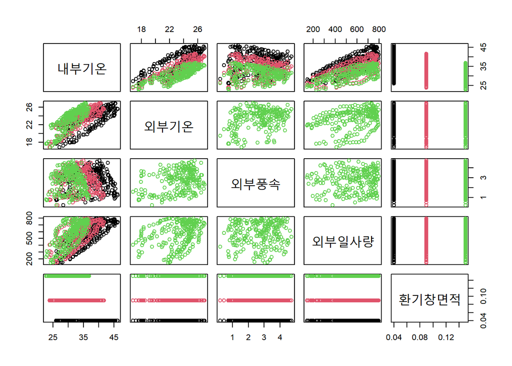

```r
pairs(ex1,col=factor(ex1$환기창면적))
```

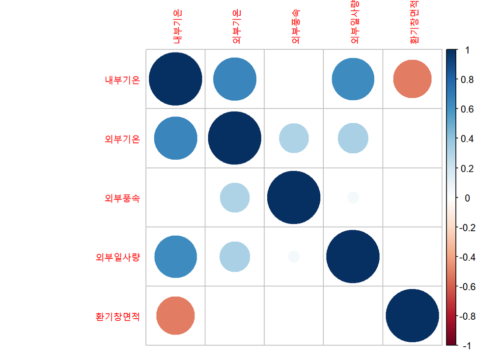

```r
library(corrplot)
corrplot(cor(ex1)) # 상관계수행렬을 그림으로 표현해주는 함수
```

- 그리고 각 변수에 대한 기초통계량은 다음과 같이 계산된다.

```r
library(psych)
describe(ex1) # 각 변수에 대한 기초통계량을 계산해주는 함수
```

```
##            vars   n   mean     sd median trimmed    mad    min    max  range
## 내부기온      1 735  33.96   4.99  33.80   33.86   5.04  22.70  46.20  23.50
## 외부기온      2 735  23.39   2.30  24.00   23.66   1.93  16.80  27.00  10.20
## 외부풍속      3 735   2.71   1.08   2.87    2.73   1.29   0.21   4.74   4.54
## 외부일사량    4 735 568.60 171.31 601.10  584.32 191.40 143.00 795.20 652.20
## 환기창면적    5 735   0.09   0.04   0.09    0.09   0.07   0.04   0.15   0.11
##             skew kurtosis   se
## 내부기온    0.18    -0.54 0.18
## 외부기온   -0.98     0.30 0.08
## 외부풍속   -0.26    -0.99 0.04
## 외부일사량 -0.63    -0.61 6.32
## 환기창면적  0.11    -1.50 0.00
```

- 내부기온을 반응변수로 하여 각 변수의 주효과와 환기창면적과의 교호작용을 고려한 다중선형회귀모형을 적합하면 다음과 같다.

```r
m_no <- lm(내부기온~외부기온+외부풍속+외부일사량+환기창면적+외부기온:환기창면적+외부풍속:환기창면적+외부일사량:환기창면적,data=plantno) # 다중회귀모형 구축 함수
summary(m_no)
```

```
##
## Call:
## lm(formula = 내부기온 ~ 외부기온 + 외부풍속 + 외부일사량 + 환기창면적 +
##     외부기온:환기창면적 + 외부풍속:환기창면적 + 외부일사량:환기창면적,
##     data = plantno)
##
## Residuals:
##     Min      1Q  Median      3Q     Max
## -3.7131 -0.7215  0.0846  0.7920  3.3806
##
## Coefficients:
##                         Estimate Std. Error t value Pr(>|t|)
## (Intercept)           -4.1647703  1.0083972  -4.130 4.05e-05 ***
## 외부기온               1.4170599  0.0476479  29.740  < 2e-16 ***
## 외부풍속              -0.7577987  0.0962141  -7.876 1.23e-14 ***
## 외부일사량             0.0216598  0.0006085  35.597  < 2e-16 ***
## 환기창면적            44.3856511  9.7333942   4.560 6.00e-06 ***
## 외부기온:환기창면적   -1.8902906  0.4599142  -4.110 4.41e-05 ***
## 외부풍속:환기창면적   -1.7896334  0.9286917  -1.927   0.0544 .
## 외부일사량:환기창면적 -0.0913180  0.0058731 -15.548  < 2e-16 ***
## ---
## Signif. codes:  0 '***' 0.001 '**' 0.01 '*' 0.05 '.' 0.1 ' ' 1
##
## Residual standard error: 1.156 on 727 degrees of freedom
## Multiple R-squared:  0.9468, Adjusted R-squared:  0.9462
## F-statistic:  1847 on 7 and 727 DF,  p-value: < 2.2e-16
```

- 모형적합 결과 외부풍속과 환기창면적과이 교호작용이 유의수준 0.05에서 유의미하지 않다.
- 그리고 교호작용들 중 외부일사량과 환기창면적 사이의 교호작용에 대한 t 통계량의 절대값이 가장 크므로 이를 가장 중요한 교호작용으로 결정한다.
- 조정된 결정계수의 값이 $R^2_{adj}=0.9462$이다.

#### Best subset selection

- 여러 측도들을 이용하여 모형에 포함될 변수를 적절히 선택해 보도록 하겠다.

```r
library(leaps)
# 다양한 측도에 따라 모형에 포함될 변수의 개수를 결정해주는 함수
ms0 <- regsubsets(내부기온~외부기온+외부풍속+외부일사량+환기창면적+외부기온:환기창면적+외부풍속:환기창면적+외부일사량:환기창면적,data=plantno,nvmax=7)
ms0.summary <- summary(ms0)
ms0.summary
```

```
## Subset selection object
## Call: regsubsets.formula(내부기온 ~ 외부기온 + 외부풍속 + 외부일사량 +
##     환기창면적 + 외부기온:환기창면적 + 외부풍속:환기창면적 +
##     외부일사량:환기창면적, data = plantno, nvmax = 7)
## 7 Variables  (and intercept)
##                       Forced in Forced out
## 외부기온                  FALSE      FALSE
## 외부풍속                  FALSE      FALSE
## 외부일사량                FALSE      FALSE
## 환기창면적                FALSE      FALSE
## 외부기온:환기창면적       FALSE      FALSE
## 외부풍속:환기창면적       FALSE      FALSE
## 외부일사량:환기창면적     FALSE      FALSE
## 1 subsets of each size up to 7
## Selection Algorithm: exhaustive
##          외부기온 외부풍속 외부일사량 환기창면적 외부기온:환기창면적
## 1  ( 1 ) "*"      " "      " "        " "        " "
## 2  ( 1 ) "*"      " "      " "        " "        " "
## 3  ( 1 ) "*"      " "      "*"        " "        " "
## 4  ( 1 ) "*"      "*"      "*"        " "        " "
## 5  ( 1 ) "*"      "*"      "*"        " "        " "
## 6  ( 1 ) "*"      "*"      "*"        "*"        "*"
## 7  ( 1 ) "*"      "*"      "*"        "*"        "*"
##          외부풍속:환기창면적 외부일사량:환기창면적
## 1  ( 1 ) " "                 " "
## 2  ( 1 ) "*"                 " "
## 3  ( 1 ) " "                 "*"
## 4  ( 1 ) " "                 "*"
## 5  ( 1 ) "*"                 "*"
## 6  ( 1 ) " "                 "*"
## 7  ( 1 ) "*"                 "*"
```

```r
par(mfrow=c(2,2))
# RSS=SSE
plot(ms0.summary$rss,xlab="Number of Variables",ylab="RSS",type="l")
# Adj R^2
plot(ms0.summary$adjr2,xlab="Number of Variables",ylab="Adjusted RSq",type="l")
which.max(ms0.summary$adjr2)
```

```
## [1] 7
```

```r
points(which.max(ms0.summary$adjr2)
,ms0.summary$adjr2[which.max(ms0.summary$adjr2)
], col="red",cex=2,pch=20)
# Cp
plot(ms0.summary$cp,xlab="Number of Variables",ylab="Cp",type='l')
which.min(ms0.summary$cp)
```

```
## [1] 7
```

```r
points(which.min(ms0.summary$cp)
,ms0.summary$cp[which.min(ms0.summary$cp)
],col="red",cex=2,pch=20)
# BIC
plot(ms0.summary$bic,xlab="Number of Variables",ylab="BIC",type='l')
which.min(ms0.summary$bic)
```

```
## [1] 6
```

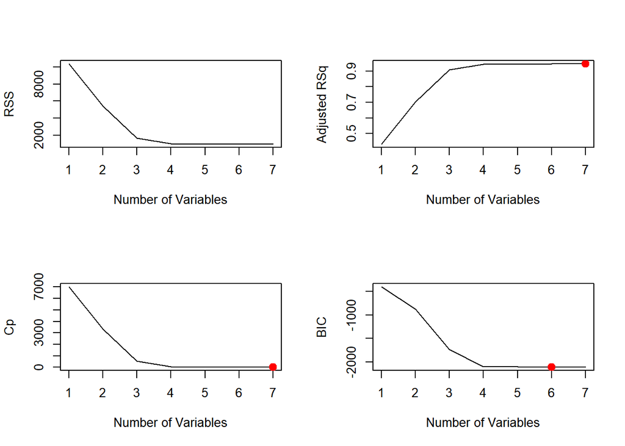

```r
points(which.min(ms0.summary$bic)
,ms0.summary$bic[which.min(ms0.summary$bic)
],col="red",cex=2,pch=20)
```

```r
par(mfrow=c(1,1))
```

- 6~7개의 변수가 선택되었고, 6개의 변수를 고려한다면 외부풍속과 환기창면적과의 교호작용이 제거될 수 있다.
- 전체적으로 4개 정도의 독립변수가 포함되면 변수선택 측도가 안정화되는 경향이 보인다. 환기창면적 및 환기창면적과 외부기온과의 교호작용이 추가로 제거될 수 있다.

#### 교차타당검증에 의한 모형 비교

- 지금부터는 train:test=7:3 으로 데이터를 나누어서 몇 개의 후보 모형들의 test RMSE를 계산하여 보겠다. 이 값이 작을수록 예측력이 우수한 모형이라고 볼 수 있다.
- 먼저 데이터를 임의로 train:test=7:3 의 비율로 나눈다. train data는 모형구축 시, test data는 구축된 모형을 평가 시 사용한다.
- 모형에 대한 성능은 test RMSE와 SSE/SST를 바탕으로 실시하며, 두가지 기준 모두 그 값이 작을수록 모형의 예측력이 우수하다고 판단하면 된다.
- $RMSE=\sqrt{{\frac {1}{n} \sum_{i=1}^{n} (y_{i}-\hat{y_{i}})^{2}}}$
- $SSE/SST=\frac {\sum_{i=1}^{n} (y_{i}-\hat{y_{i}})^{2}} {\sum_{i=1}^{n} (y_{i}-\bar{y})^{2}}$

```r
set.seed(5790)
train.index <- sample(1:nrow(plantno), round(nrow(plantno)*7/10), replace=F)
ex1_train <- plantno[train.index,]
ex1_test <- plantno[-train.index,]
```

```r
# model1 : 모든 주효과, 그리고 환기창면적과 다른 변수들 사이의 교호작용을 포함한 모형
m0 <- lm(내부기온~외부기온+외부풍속+외부일사량+환기창면적+환기창면적*외부기온+환기창면적*외부풍속+환기창면적*외부일사량,data=ex1_train)
y_hat0 <- predict(m0,ex1_test)
RMSE0 <- sqrt(mean((ex1_test$내부기온-y_hat0)^2))
SSE0 <- sum((ex1_test$내부기온-y_hat0)^2)
SST0 <- sum((ex1_test$내부기온-mean(ex1_test$내부기온))^2)
result0 <- data.frame(ex1_test$내부기온, y_hat0, ex1_test$내부기온-y_hat0)
colnames(result0) <- c('y','yhat','y-yhat')
RMSE0 # test RMSE
```

```
## [1] 1.144583
```

```r
SSE0/SST0 # SSE/SST
```

```
## [1] 0.05069566
```

```r
head(result0,12)
```

```
##       y     yhat     y-yhat
## 3  29.1 28.69708  0.4029221
## 5  30.6 29.26291  1.3370900
## 7  31.7 29.98604  1.7139566
## 10 32.6 31.37674  1.2232625
## 12 35.2 34.13939  1.0606104
## 17 37.2 36.75462  0.4453811
## 20 39.1 38.39290  0.7071010
## 24 41.6 40.30733  1.2926692
## 33 39.5 38.92431  0.5756933
## 51 28.6 28.99184 -0.3918401
## 60 38.8 37.35898  1.4410200
## 62 40.8 38.41950  2.3804980
```

```r
# model2 : Adj R^2, Cp, BIC 등의 기준을 바탕으로 선택된 모형 (교호작용이 있는 경우는 주효과 포함)
m0 <- lm(내부기온~외부기온+외부풍속+외부일사량+환기창면적+환기창면적*외부기온+환기창면적*외부일사량,data=ex1_train)
y_hat0 <- predict(m0,ex1_test)
RMSE1 <- sqrt(mean((ex1_test$내부기온-y_hat0)^2))
SSE1 <- sum((ex1_test$내부기온-y_hat0)^2)
SST1 <- sum((ex1_test$내부기온-mean(ex1_test$내부기온))^2)
result1 <- data.frame(ex1_test$내부기온, y_hat0, ex1_test$내부기온-y_hat0)
colnames(result1) <- c('y','yhat','y-yhat')
RMSE1 # test RMSE
```

```
## [1] 1.132952
```

```r
SSE1/SST1 # SSE/SST
```

```
## [1] 0.04967056
```

```r
head(result1,12)
```

```
##       y     yhat     y-yhat
## 3  29.1 28.75882  0.3411840
## 5  30.6 29.14025  1.4597506
## 7  31.7 29.77189  1.9281101
## 10 32.6 31.09627  1.5037260
## 12 35.2 33.93478  1.2652180
## 17 37.2 36.49555  0.7044542
## 20 39.1 38.16193  0.9380656
## 24 41.6 40.17978  1.4202232
## 33 39.5 38.78296  0.7170437
## 51 28.6 29.12282 -0.5228235
## 60 38.8 37.58036  1.2196441
## 62 40.8 38.59588  2.2041243
```

```r
# model3 : 모든 주효과와 가장 중요한 교호작용 1가지를 포함한 모형
m0 <- lm(내부기온~외부기온+외부풍속+외부일사량+환기창면적+환기창면적*외부일사량,data=ex1_train)
y_hat0 <- predict(m0,ex1_test)
RMSE2 <- sqrt(mean((ex1_test$내부기온-y_hat0)^2))
SSE2 <- sum((ex1_test$내부기온-y_hat0)^2)
SST2 <- sum((ex1_test$내부기온-mean(ex1_test$내부기온))^2)
result2 <- data.frame(ex1_test$내부기온, y_hat0, ex1_test$내부기온-y_hat0)
colnames(result2) <- c('y','yhat','y-yhat')
RMSE2 # test RMSE
```

```
## [1] 1.159708
```

```r
SSE2/SST2 # SSE/SST
```

```
## [1] 0.05204434
```

```r
head(result2,12)
```

```
##       y     yhat     y-yhat
## 3  29.1 29.32048 -0.2204828
## 5  30.6 29.70428  0.8957207
## 7  31.7 30.35641  1.3435867
## 10 32.6 31.68806  0.9119369
## 12 35.2 34.39578  0.8042225
## 17 37.2 36.84181  0.3581862
## 20 39.1 38.42345  0.6765517
## 24 41.6 40.29640  1.3035992
## 33 39.5 38.77844  0.7215573
## 51 28.6 29.59770 -0.9977036
## 60 38.8 37.84099  0.9590073
## 62 40.8 38.82306  1.9769364
```

- 결과적으로 3가지 모형들 중 변수선택의 측도 관점에서 결정된 모형이 test error를 가장 작게 하였다.
- 하지만, test error 값들에 큰 차이가 없어 단순한 모형(교호작용 1개만 포함한 모형)을 선택하는 것도 좋아 보인다.
- `:`표시는 교호작용을 의미함.
- model1 : 모든 주효과, 그리고 환기창면적과 다른 변수들 사이의 교호작용을 포함한 모형
  - 반응변수 : 내부기온
  - 설명변수 : 외부기온, 외부풍속, 외부일사량, 환기창면적, 환기창면적:외부기온, 환기창면적:외부풍속, 환기창면적*외부일사량
  - RMSE=1.1446, SSE/SST=0.0507
- model2 : Adj R^2, Cp, BIC 등의 기준을 바탕으로 선택된 모형 (교호작용이 있는 경우는 주효과 포함)
  - 반응변수 : 내부기온
  - 설명변수 : 외부기온, 외부풍속, 외부일사량, 환기창면적, 환기창면적:외부기온, 환기창면적:외부일사량
  - RMSE=1.1330, SSE/SST=0.0497
- model3 : 모든 주효과와 가장 중요한 교호작용 1가지를 포함한 모형
  - 반응변수 : 내부기온
  - 설명변수 : 외부기온, 외부풍속, 외부일사량, 환기창면적, 환기창면적:외부일사량
  - RMSE=1.1597, SSE/SST=0.0520
- 참고로, 사전분석을 통해 외부풍속과 외부일사량과의 교호작용이 어느 정도 의미 있게 관측되었다. 만약 두 개의 다른 형태의 교호작용을 포함시키고자 한다면 다음과 같은 모형을 고려해볼 수 있다.
- 결과적으로, 교호작용을 1개만 포함하려면 환기창면적과 외부일사량이 포함되는 것이 좋고, 그 다음으로 의미 있는 것이 외부풍속과 외부일사량과의 교호작용인 것으로 보인다.

```r
# model4 : 모든 주효과와 가장 중요한 교호작용 1가지를 포함한 모형
m0 <- lm(내부기온~외부기온+외부풍속+외부일사량+환기창면적+환기창면적*외부일사량+외부풍속*외부일사량,data=ex1_train)
y_hat0 <- predict(m0,ex1_test)
RMSE3 <- sqrt(mean((ex1_test$내부기온-y_hat0)^2))
SSE3 <- sum((ex1_test$내부기온-y_hat0)^2)
SST3 <- sum((ex1_test$내부기온-mean(ex1_test$내부기온))^2)
result3 <- data.frame(ex1_test$내부기온, y_hat0, ex1_test$내부기온-y_hat0)
colnames(result3) <- c('y','yhat','y-yhat')
RMSE3 # test RMSE
```

```
## [1] 1.08257
```

```r
SSE3/SST3 # SSE/SST
```

```
## [1] 0.0453511
```

```r
head(result3,12)
```

```
##       y     yhat     y-yhat
## 3  29.1 29.33849 -0.2384893
## 5  30.6 30.02841  0.5715946
## 7  31.7 30.69560  1.0043960
## 10 32.6 31.87824  0.7217609
## 12 35.2 34.50496  0.6950396
## 17 37.2 36.55756  0.6424422
## 20 39.1 38.04431  1.0556857
## 24 41.6 40.04667  1.5533320
## 33 39.5 38.57866  0.9213406
## 51 28.6 29.34362 -0.7436207
## 60 38.8 38.33082  0.4691849
## 62 40.8 39.34955  1.4504513
```

#### 아래는 네 모형에 대한 데이터 전체 적합결과이다.

#### 1. model1

```r
summary(lm(내부기온~외부기온+외부풍속+외부일사량+환기창면적+환기창면적*외부기온+환기창면적*외부풍속+환기창면적*외부일사량,data=plantno) )
```

```
##
## Call:
## lm(formula = 내부기온 ~ 외부기온 + 외부풍속 + 외부일사량 + 환기창면적 +
##     환기창면적 * 외부기온 + 환기창면적 * 외부풍속 + 환기창면적 *
##     외부일사량, data = plantno)
##
## Residuals:
##     Min      1Q  Median      3Q     Max
## -3.7131 -0.7215  0.0846  0.7920  3.3806
##
## Coefficients:
##                         Estimate Std. Error t value Pr(>|t|)
## (Intercept)           -4.1647703  1.0083972  -4.130 4.05e-05 ***
## 외부기온               1.4170599  0.0476479  29.740  < 2e-16 ***
## 외부풍속              -0.7577987  0.0962141  -7.876 1.23e-14 ***
## 외부일사량             0.0216598  0.0006085  35.597  < 2e-16 ***
## 환기창면적            44.3856511  9.7333942   4.560 6.00e-06 ***
## 외부기온:환기창면적   -1.8902906  0.4599142  -4.110 4.41e-05 ***
## 외부풍속:환기창면적   -1.7896334  0.9286917  -1.927   0.0544 .
## 외부일사량:환기창면적 -0.0913180  0.0058731 -15.548  < 2e-16 ***
## ---
## Signif. codes:  0 '***' 0.001 '**' 0.01 '*' 0.05 '.' 0.1 ' ' 1
##
## Residual standard error: 1.156 on 727 degrees of freedom
## Multiple R-squared:  0.9468, Adjusted R-squared:  0.9462
## F-statistic:  1847 on 7 and 727 DF,  p-value: < 2.2e-16
```

#### 2. model2

```r
summary(lm(내부기온~외부기온+외부풍속+외부일사량+환기창면적+환기창면적*외부기온+환기창면적*외부일사량,data=plantno) )
```

```
##
## Call:
## lm(formula = 내부기온 ~ 외부기온 + 외부풍속 + 외부일사량 + 환기창면적 +
##     환기창면적 * 외부기온 + 환기창면적 * 외부일사량, data = plantno)
##
## Residuals:
##     Min      1Q  Median      3Q     Max
## -3.7139 -0.6943  0.0725  0.8129  3.4767
##
## Coefficients:
##                         Estimate Std. Error t value Pr(>|t|)
## (Intercept)           -4.2731832  1.0087013  -4.236 2.56e-05 ***
## 외부기온               1.4425437  0.0458613  31.455  < 2e-16 ***
## 외부풍속              -0.9248312  0.0418402 -22.104  < 2e-16 ***
## 외부일사량             0.0215980  0.0006088  35.479  < 2e-16 ***
## 환기창면적            45.5472173  9.7328004   4.680 3.42e-06 ***
## 외부기온:환기창면적   -2.1633308  0.4383596  -4.935 9.94e-07 ***
## 외부일사량:환기창면적 -0.0906561  0.0058740 -15.434  < 2e-16 ***
## ---
## Signif. codes:  0 '***' 0.001 '**' 0.01 '*' 0.05 '.' 0.1 ' ' 1
##
## Residual standard error: 1.158 on 728 degrees of freedom
## Multiple R-squared:  0.9465, Adjusted R-squared:  0.946
## F-statistic:  2146 on 6 and 728 DF,  p-value: < 2.2e-16
```

#### 3. model3

```r
summary(lm(내부기온~외부기온+외부풍속+외부일사량+환기창면적+환기창면적*외부일사량,data=plantno) )
```

```
##
## Call:
## lm(formula = 내부기온 ~ 외부기온 + 외부풍속 + 외부일사량 + 환기창면적 +
##     환기창면적 * 외부일사량, data = plantno)
##
## Residuals:
##     Min      1Q  Median      3Q     Max
## -3.7137 -0.7179  0.1042  0.8325  3.5767
##
## Coefficients:
##                         Estimate Std. Error t value Pr(>|t|)
## (Intercept)           -0.0550419  0.5441578  -0.101    0.919
## 외부기온               1.2406328  0.0210497  58.938   <2e-16 ***
## 외부풍속              -0.9248312  0.0425051 -21.758   <2e-16 ***
## 외부일사량             0.0224840  0.0005909  38.049   <2e-16 ***
## 환기창면적             0.3528462  3.3481030   0.105    0.916
## 외부일사량:환기창면적 -0.1001488  0.0056383 -17.762   <2e-16 ***
## ---
## Signif. codes:  0 '***' 0.001 '**' 0.01 '*' 0.05 '.' 0.1 ' ' 1
##
## Residual standard error: 1.177 on 729 degrees of freedom
## Multiple R-squared:  0.9447, Adjusted R-squared:  0.9443
## F-statistic:  2490 on 5 and 729 DF,  p-value: < 2.2e-16
```

#### 4. model4

```r
summary(lm(내부기온~외부기온+외부풍속+외부일사량+환기창면적+환기창면적*외부일사량+외부풍속*외부일사량,data=plantno) )
```

```
##
## Call:
## lm(formula = 내부기온 ~ 외부기온 + 외부풍속 + 외부일사량 + 환기창면적 +
##     환기창면적 * 외부일사량 + 외부풍속 * 외부일사량, data = plantno)
##
## Residuals:
##     Min      1Q  Median      3Q     Max
## -3.7538 -0.6855  0.1190  0.7572  3.0884
##
## Coefficients:
##                         Estimate Std. Error t value Pr(>|t|)
## (Intercept)           -2.3868488  0.5717914  -4.174 3.35e-05 ***
## 외부기온               1.1838059  0.0208108  56.884  < 2e-16 ***
## 외부풍속               0.3906147  0.1463358   2.669  0.00777 **
## 외부일사량             0.0288271  0.0008790  32.797  < 2e-16 ***
## 환기창면적             0.3528462  3.1657571   0.111  0.91128
## 외부일사량:환기창면적 -0.1001488  0.0053312 -18.785  < 2e-16 ***
## 외부풍속:외부일사량   -0.0022655  0.0002423  -9.349  < 2e-16 ***
## ---
## Signif. codes:  0 '***' 0.001 '**' 0.01 '*' 0.05 '.' 0.1 ' ' 1
##
## Residual standard error: 1.113 on 728 degrees of freedom
## Multiple R-squared:  0.9506, Adjusted R-squared:  0.9502
## F-statistic:  2336 on 6 and 728 DF,  p-value: < 2.2e-16
```

#### 해석

- 네 모형의 설명력은 대동소이하다.
- 외부기온의 증가는 내부기온의 상승과 연관된다. 외부풍속은 내부기온의 하강과 연관된다.
- 환기창 면적과 외부일사량과의 교호작용이 음수이다. 이에 따라 환기창면적이 커질 수록 외부일사량은 제한적인 영향만을 내부기온에 가지게 된다.

### 2.2 작물이 있을 때

#### Multiple Linear Regression Model

- 먼저 변수들 간의 상관관계를 파악하기 위해 상관분석을 실시한다.

```r
ex1 <- plantyes[,c(2,1,10,11,13)]
head(ex1)
```

```
##   내부기온 외부기온 외부풍속 외부일사량 환기창면적
## 1     31.1     22.9    1.398      372.7       0.15
## 2     29.7     22.8    1.326      309.9       0.15
## 3     29.7     23.3    0.835      291.9       0.15
## 4     29.8     23.6    0.943      297.5       0.15
## 5     30.0     24.0    1.481      335.4       0.15
## 6     33.3     25.1    1.132      549.7       0.15
```

```r
cor(ex1)
```

```
##              내부기온    외부기온    외부풍속  외부일사량  환기창면적
## 내부기온    1.0000000  0.77533900 -0.10014625  0.77862921 -0.33399269
## 외부기온    0.7753390  1.00000000  0.12445561  0.47323743 -0.08617862
## 외부풍속   -0.1001462  0.12445561  1.00000000  0.01247939  0.10718424
## 외부일사량  0.7786292  0.47323743  0.01247939  1.00000000 -0.01979362
## 환기창면적 -0.3339927 -0.08617862  0.10718424 -0.01979362  1.00000000
```

- 산점도행렬과 상관계수그림을 그리면 다음과 같다.

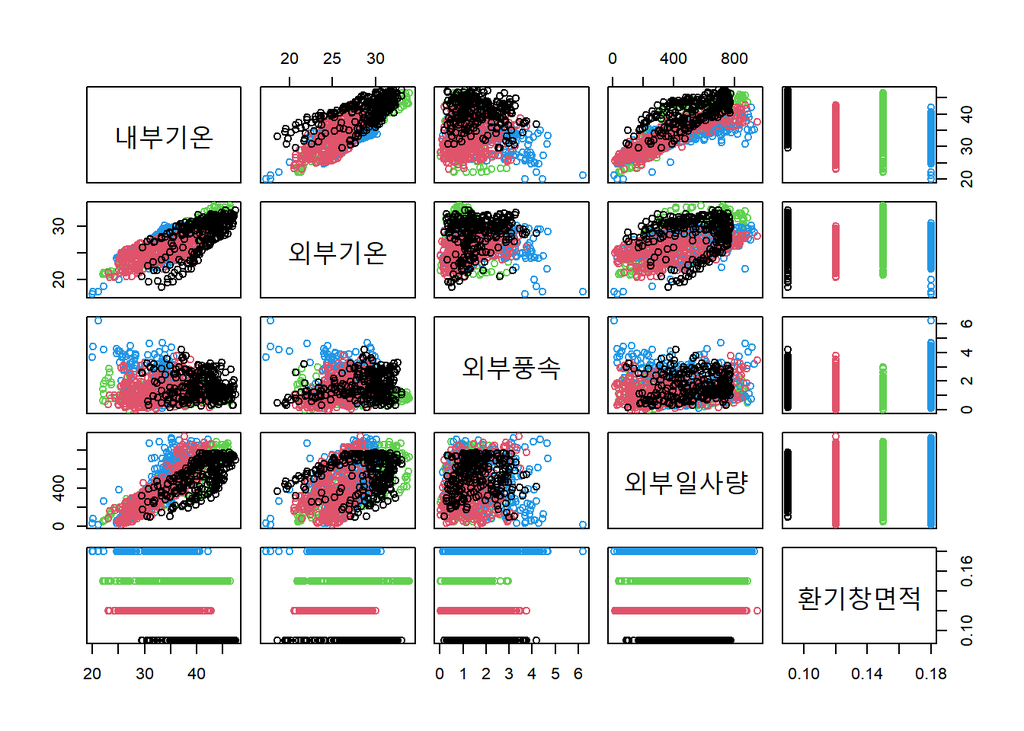

```r
pairs(ex1,col=factor(ex1$환기창면적))
```

- 환기창면적과 다른 주효과들간의 뚜렷한 교호작용이 관측되지는 않는다.
- 독립변수들과 내부기온과의 연관성의 방향은 작물이 없을 때와 유사해 보인다.

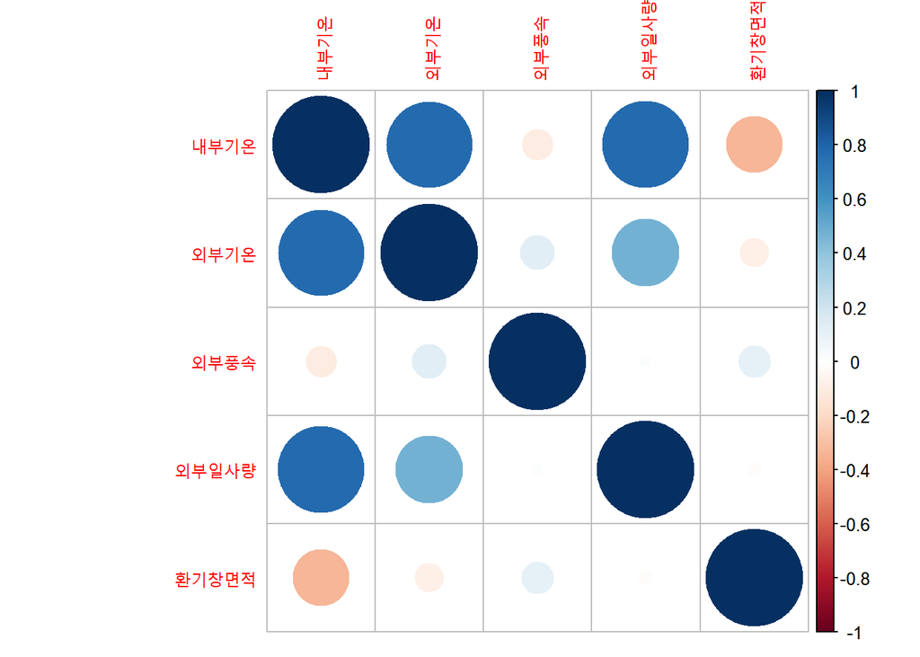

```r
library(corrplot)
corrplot(cor(ex1))
```

- 그리고 각 변수에 대한 기초통계량은 다음과 같이 계산된다.

```r
library(psych)
describe(ex1)
```

```
##            vars    n   mean     sd median trimmed    mad   min    max  range
## 내부기온      1 1055  35.43   5.69  35.40   35.47   5.93 20.00  47.40  27.40
## 외부기온      2 1055  26.91   2.99  26.90   26.94   3.26 17.30  33.90  16.60
## 외부풍속      3 1055   1.50   0.92   1.30    1.41   0.83  0.00   6.22   6.21
## 외부일사량    4 1055 459.27 225.19 459.20  460.76 275.02 10.04 950.00 939.96
## 환기창면적    5 1055   0.13   0.03   0.12    0.13   0.04  0.09   0.18   0.09
##             skew kurtosis   se
## 내부기온   -0.08    -0.63 0.18
## 외부기온   -0.12    -0.42 0.09
## 외부풍속    0.97     0.80 0.03
## 외부일사량 -0.02    -1.02 6.93
## 환기창면적  0.12    -1.38 0.00
```

- 내부기온을 반응변수로 하여 각 변수의 주효과와 모든 가능한 교호작용을 고려한 다중선형회귀모형을 적합하면 다음과 같다.
- 작물이 없을 때와는 달리 모든 교호작용을 함께 고려한 것은, 사전분석 결과 환기창면적과 다른 변수들과의 교호작용 뿐 아니라 다른 효과들도 비교적 유의미하게 관측되었기 때문이다.

```r
m_yes <- lm(내부기온~(외부기온+외부풍속+외부일사량+환기창면적)^2,data=plantyes)
summary(m_yes)
```

```
##
## Call:
## lm(formula = 내부기온 ~ (외부기온 + 외부풍속 + 외부일사량 + 환기창면적)^2,
##     data = plantyes)
##
## Residuals:
##     Min      1Q  Median      3Q     Max
## -3.7669 -0.8949 -0.0193  0.8185  5.6445
##
## Coefficients:
##                         Estimate Std. Error t value Pr(>|t|)
## (Intercept)           -1.153e+01  1.854e+00  -6.220 7.18e-10 ***
## 외부기온               1.593e+00  7.052e-02  22.589  < 2e-16 ***
## 외부풍속               9.832e-01  5.044e-01   1.949 0.051539 .
## 외부일사량             5.302e-02  2.039e-03  26.000  < 2e-16 ***
## 환기창면적             6.914e+00  1.225e+01   0.564 0.572598
## 외부기온:외부풍속     -5.659e-02  1.656e-02  -3.418 0.000655 ***
## 외부기온:외부일사량   -9.588e-04  6.714e-05 -14.280  < 2e-16 ***
## 외부기온:환기창면적   -7.036e-01  4.694e-01  -1.499 0.134202
## 외부풍속:외부일사량   -1.998e-03  2.148e-04  -9.302  < 2e-16 ***
## 외부풍속:환기창면적    2.447e+00  1.353e+00   1.808 0.070850 .
## 외부일사량:환기창면적 -7.761e-02  6.317e-03 -12.286  < 2e-16 ***
## ---
## Signif. codes:  0 '***' 0.001 '**' 0.01 '*' 0.05 '.' 0.1 ' ' 1
##
## Residual standard error: 1.295 on 1044 degrees of freedom
## Multiple R-squared:  0.9486, Adjusted R-squared:  0.9481
## F-statistic:  1927 on 10 and 1044 DF,  p-value: < 2.2e-16
```

- 모형적합 결과 환기창면적, 그리고 환기창면적과 외부풍속과의 교호작용이 유의수준 0.05에서 유의미하지 않았다. 조정된 결정계수의 값이 $R^2_{adj}=0.9481$이므로 작물이 없을 때와 비슷한 수준이다.
- 그리고 여러 교호작용들 중 t 통계량의 절대값이 가장 큰 외부일사량과 외부기온 사이의 교호작용을 1차적으로 고려해 볼 수 있다. 외부일사량과 환기창면적 사이의 교호작용, 외부풍속과 외부일사량과의 교호작용 또한 유의미해 보인다.
- 전체적으로 환기창면적과의 교호작용 뿐 아니라 다양한 교호작용들이 유의미하게 나타난다.

#### Best subset selection

- 여러 측도들을 이용하여 모형에 포함될 변수를 적절히 선택해 보도록 하겠다.

```r
library(leaps)
ms0 <- regsubsets(내부기온~(외부기온+외부풍속+외부일사량+환기창면적)^2,data=plantyes,nvmax=10)
ms0.summary <- summary(ms0)
ms0.summary
```

```
## Subset selection object
## Call: regsubsets.formula(내부기온 ~ (외부기온 + 외부풍속 + 외부일사량 +
##     환기창면적)^2, data = plantyes, nvmax = 10)
## 10 Variables  (and intercept)
##                       Forced in Forced out
## 외부기온                  FALSE      FALSE
## 외부풍속                  FALSE      FALSE
## 외부일사량                FALSE      FALSE
## 환기창면적                FALSE      FALSE
## 외부기온:외부풍속         FALSE      FALSE
## 외부기온:외부일사량       FALSE      FALSE
## 외부기온:환기창면적       FALSE      FALSE
## 외부풍속:외부일사량       FALSE      FALSE
## 외부풍속:환기창면적       FALSE      FALSE
## 외부일사량:환기창면적     FALSE      FALSE
## 1 subsets of each size up to 10
## Selection Algorithm: exhaustive
##           외부기온 외부풍속 외부일사량 환기창면적 외부기온:외부풍속
## 1  ( 1 )  " "      " "      " "        " "        " "
## 2  ( 1 )  " "      " "      " "        " "        " "
## 3  ( 1 )  "*"      " "      "*"        " "        " "
## 4  ( 1 )  "*"      " "      "*"        " "        " "
## 5  ( 1 )  "*"      " "      "*"        " "        " "
## 6  ( 1 )  "*"      " "      "*"        " "        " "
## 7  ( 1 )  "*"      "*"      "*"        " "        "*"
## 8  ( 1 )  "*"      "*"      "*"        " "        "*"
## 9  ( 1 )  "*"      "*"      "*"        " "        "*"
## 10  ( 1 ) "*"      "*"      "*"        "*"        "*"
##           외부기온:외부일사량 외부기온:환기창면적 외부풍속:외부일사량
## 1  ( 1 )  "*"                 " "                 " "
## 2  ( 1 )  "*"                 " "                 " "
## 3  ( 1 )  " "                 " "                 " "
## 4  ( 1 )  " "                 " "                 "*"
## 5  ( 1 )  "*"                 " "                 "*"
## 6  ( 1 )  "*"                 "*"                 "*"
## 7  ( 1 )  "*"                 " "                 "*"
## 8  ( 1 )  "*"                 "*"                 "*"
## 9  ( 1 )  "*"                 "*"                 "*"
## 10  ( 1 ) "*"                 "*"                 "*"
##           외부풍속:환기창면적 외부일사량:환기창면적
## 1  ( 1 )  " "                 " "
## 2  ( 1 )  " "                 "*"
## 3  ( 1 )  " "                 "*"
## 4  ( 1 )  " "                 "*"
## 5  ( 1 )  " "                 "*"
## 6  ( 1 )  " "                 "*"
## 7  ( 1 )  " "                 "*"
## 8  ( 1 )  " "                 "*"
## 9  ( 1 )  "*"                 "*"
## 10  ( 1 ) "*"                 "*"
```

```r
par(mfrow=c(2,2))
# RSS=SSE
plot(ms0.summary$rss,xlab="Number of Variables",ylab="RSS",type="l")
# Adj R^2
plot(ms0.summary$adjr2,xlab="Number of Variables",ylab="Adjusted RSq",type="l")
which.max(ms0.summary$adjr2)
```

```
## [1] 9
```

```r
points(which.max(ms0.summary$adjr2)
,ms0.summary$adjr2[which.max(ms0.summary$adjr2)
], col="red",cex=2,pch=20)
# Cp
plot(ms0.summary$cp,xlab="Number of Variables",ylab="Cp",type='l')
which.min(ms0.summary$cp)
```

```
## [1] 9
```

```r
points(which.min(ms0.summary$cp)
,ms0.summary$cp[which.min(ms0.summary$cp)
],col="red",cex=2,pch=20)
# BIC
plot(ms0.summary$bic,xlab="Number of Variables",ylab="BIC",type='l')
which.min(ms0.summary$bic)
```

```
## [1] 7
```

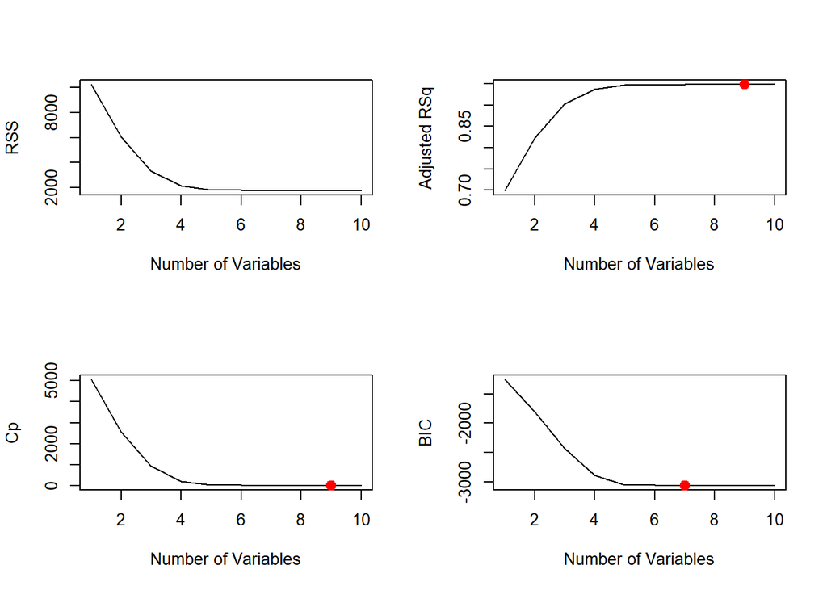

```r
points(which.min(ms0.summary$bic)
,ms0.summary$bic[which.min(ms0.summary$bic)
],col="red",cex=2,pch=20)
```

```r
par(mfrow=c(1,1))
```

- 전체적으로 변수가 5~7개 정도면 안정화되는 경향이 보인다.

#### 교차타당검증에 의한 모형 비교

- 지금부터는 train:test=7:3 으로 데이터를 나누어서 몇 개의 후보 모형들의 test RMSE를 계산하여 보겠다. 이 값이 작을수록 예측력이 우수한 모형이라고 볼 수 있다.
- 먼저 데이터를 임의로 train:test=7:3 의 비율로 나눈다. train data는 모형구축 시, test data는 구축된 모형을 평가 시 사용한다.
- 모형에 대한 성능은 test RMSE와 SSE/SST를 바탕으로 실시하며, 두가지 기준 모두 그 값이 작을수록 모형의 예측력이 우수하다고 판단하면 된다.
- $RMSE=\sqrt{{\frac {1}{n} \sum_{i=1}^{n} (y_{i}-\hat{y_{i}})^{2}}}$
- $SSE/SST=\frac {\sum_{i=1}^{n} (y_{i}-\hat{y_{i}})^{2}} {\sum_{i=1}^{n} (y_{i}-\bar{y})^{2}}$

```r
set.seed(5790)
train.index <- sample(1:nrow(plantyes), round(nrow(plantyes)*7/10), replace=F)
ex1_train <- plantyes[train.index,]
ex1_test <- plantyes[-train.index,]
```

```r
# model1 : 모든 주효과 및 교호작용을 포함한 모형
m0 <- lm(내부기온~(외부기온+외부풍속+외부일사량+환기창면적)^2,data=ex1_train)
y_hat0 <- predict(m0,ex1_test)
RMSE0 <- sqrt(mean((ex1_test$내부기온-y_hat0)^2))
SSE0 <- sum((ex1_test$내부기온-y_hat0)^2)
SST0 <- sum((ex1_test$내부기온-mean(ex1_test$내부기온))^2)
result0 <- data.frame(ex1_test$내부기온, y_hat0, ex1_test$내부기온-y_hat0)
colnames(result0) <- c('y','yhat','y-yhat')
RMSE0 # test RMSE
```

```
## [1] 1.319752
```

```r
SSE0/SST0 # SSE/SST
```

```
## [1] 0.05161563
```

```r
head(result0,12)
```

```
##       y     yhat      y-yhat
## 3  29.7 29.37317  0.32683044
## 5  30.0 30.43657 -0.43656769
## 10 35.9 37.55205 -1.65205387
## 12 38.2 39.06612 -0.86611729
## 17 37.0 37.21583 -0.21583409
## 20 38.0 39.20851 -1.20850930
## 23 37.7 37.99635 -0.29635078
## 24 38.6 38.52891  0.07109018
## 33 45.9 44.33791  1.56208603
## 39 43.1 41.80379  1.29620568
## 45 35.7 34.99387  0.70612536
## 54 22.2 22.17093  0.02906676
```

```r
# model2 : 모든 주효과, 그리고 주요한 3개의 교호작용을 포함한 모형
m0 <- lm(내부기온~외부기온+외부풍속+외부일사량+환기창면적+외부풍속*외부일사량+외부기온*외부일사량+환기창면적*외부일사량,data=ex1_train)
y_hat0 <- predict(m0,ex1_test)
RMSE1 <- sqrt(mean((ex1_test$내부기온-y_hat0)^2))
SSE1 <- sum((ex1_test$내부기온-y_hat0)^2)
SST1 <- sum((ex1_test$내부기온-mean(ex1_test$내부기온))^2)
result1 <- data.frame(ex1_test$내부기온, y_hat0, ex1_test$내부기온-y_hat0)
colnames(result1) <- c('y','yhat','y-yhat')
RMSE1 # test RMSE
```

```
## [1] 1.308672
```

```r
SSE1/SST1 # SSE/SST
```

```
## [1] 0.05075262
```

```r
head(result1,12)
```

```
##       y     yhat       y-yhat
## 3  29.7 29.32239  0.377609669
## 5  30.0 30.35617 -0.356169820
## 10 35.9 37.53910 -1.639104850
## 12 38.2 39.07543 -0.875425860
## 17 37.0 37.23235 -0.232349192
## 20 38.0 39.21950 -1.219504240
## 23 37.7 37.98828 -0.288283888
## 24 38.6 38.60863 -0.008627792
## 33 45.9 44.60408  1.295915014
## 39 43.1 42.01751  1.082490371
## 45 35.7 35.19775  0.502253563
## 54 22.2 22.12126  0.078739243
```

```r
# model3 : 모든 주효과, 그리고 외부기온과 외부일사량과의 교호작용 1개만을 포함한 모형
m0 <- lm(내부기온~외부기온+외부풍속+외부일사량+환기창면적+외부기온*외부일사량,data=ex1_train)
y_hat0 <- predict(m0,ex1_test)
RMSE2 <- sqrt(mean((ex1_test$내부기온-y_hat0)^2))
SSE2 <- sum((ex1_test$내부기온-y_hat0)^2)
SST2 <- sum((ex1_test$내부기온-mean(ex1_test$내부기온))^2)
result2 <- data.frame(ex1_test$내부기온, y_hat0, ex1_test$내부기온-y_hat0)
colnames(result2) <- c('y','yhat','y-yhat')
RMSE2 # test RMSE
```

```
## [1] 1.582317
```

```r
SSE2/SST2 # SSE/SST
```

```
## [1] 0.07419659
```

```r
head(result2,12)
```

```
##       y     yhat      y-yhat
## 3  29.7 29.32431  0.37568845
## 5  30.0 30.22441 -0.22441129
## 10 35.9 37.21037 -1.31036745
## 12 38.2 38.46539 -0.26539441
## 17 37.0 37.03098 -0.03098490
## 20 38.0 38.75297 -0.75297052
## 23 37.7 37.78725 -0.08724689
## 24 38.6 38.53164  0.06836019
## 33 45.9 44.44789  1.45210812
## 39 43.1 42.03050  1.06950163
## 45 35.7 34.85035  0.84965356
## 54 22.2 21.73842  0.46157685
```

```r
# model4 : 모든 주효과, 그리고 외부일사량과 환기창면적과의 교호작용 1개만을 포함한 모형
m0 <- lm(내부기온~외부기온+외부풍속+외부일사량+환기창면적+환기창면적*외부일사량,data=ex1_train)
y_hat0 <- predict(m0,ex1_test)
RMSE3 <- sqrt(mean((ex1_test$내부기온-y_hat0)^2))
SSE3 <- sum((ex1_test$내부기온-y_hat0)^2)
SST3 <- sum((ex1_test$내부기온-mean(ex1_test$내부기온))^2)
result3 <- data.frame(ex1_test$내부기온, y_hat0, ex1_test$내부기온-y_hat0)
colnames(result3) <- c('y','yhat','y-yhat')
RMSE3 # test RMSE
```

```
## [1] 1.466064
```

```r
SSE3/SST3 # SSE/SST
```

```
## [1] 0.06369456
```

```r
head(result3,12)
```

```
##       y     yhat      y-yhat
## 3  29.7 29.82062 -0.12062063
## 5  30.0 30.36792 -0.36792016
## 10 35.9 36.94304 -1.04304190
## 12 38.2 38.26303 -0.06302742
## 17 37.0 36.92690  0.07310245
## 20 38.0 38.80598 -0.80598493
## 23 37.7 37.78154 -0.08154163
## 24 38.6 38.51105  0.08894723
## 33 45.9 46.28688 -0.38687701
## 39 43.1 42.74821  0.35178709
## 45 35.7 34.34508  1.35491674
## 54 22.2 23.82641 -1.62640866
```

- 결과적으로 모든 주효과와 유의미한 3개의 교호작용을 포함한 모형이 가장 우수하였다.
- 교호작용을 1개만 포함하고자 할 때는 t값 기준으로는 외부기온과 외부일사량과의 교호작용이 더 강한 효과를 보였으나, test error 기준으로는 외부일사량과 환기창면적과의 교호작용을 포함한 모형이 더 우수하였다. 이것은 작물이 없을 때와 동일한 결과이다.
- `:`표시는 교호작용을 의미함.
- model1 : 모든 주효과 및 교호작용을 포함한 모형
  - 반응변수 : 내부기온
  - 설명변수 : 외부기온, 외부풍속, 외부일사량, 환기창면적, 외부기온:외부풍속, 외부기온:외부일사량, 외부기온:환기창면적, 외부풍속:외부일사량, 외부풍속:환기창면적, 외부일사량:환기창면적
  - RMSE=1.3198, SSE/SST=0.0516
- model2 : 모든 주효과, 그리고 주요한 3개의 교호작용을 포함한 모형
  - 반응변수 : 내부기온
  - 설명변수 : 외부기온, 외부풍속, 외부일사량, 환기창면적, 외부풍속:외부일사량, 외부기온:외부일사량, 환기창면적:외부일사량
  - RMSE=1.3087, SSE/SST=0.0508
- model3 : 모든 주효과, 그리고 외부기온과 외부일사량과의 교호작용 1개만을 포함한 모형
  - 반응변수 : 내부기온
  - 설명변수 : 외부기온, 외부풍속, 외부일사량, 환기창면적, 외부기온:외부일사량
  - RMSE=1.5823, SSE/SST=0.0742
- model4 : 모든 주효과, 그리고 외부일사량과 환기창면적과의 교호작용 1개만을 포함한 모형
  - 반응변수 : 내부기온
  - 설명변수 : 외부기온, 외부풍속, 외부일사량, 환기창면적, 환기창면적:외부일사량
  - RMSE=1.4661, SSE/SST=0.0637

#### 아래는 네 모형에 대한 데이터 전체 적합결과이다.

#### 1. model1

```r
summary(lm(내부기온~(외부기온+외부풍속+외부일사량+환기창면적)^2,data=plantyes) )
```

```
##
## Call:
## lm(formula = 내부기온 ~ (외부기온 + 외부풍속 + 외부일사량 + 환기창면적)^2,
##     data = plantyes)
##
## Residuals:
##     Min      1Q  Median      3Q     Max
## -3.7669 -0.8949 -0.0193  0.8185  5.6445
##
## Coefficients:
##                         Estimate Std. Error t value Pr(>|t|)
## (Intercept)           -1.153e+01  1.854e+00  -6.220 7.18e-10 ***
## 외부기온               1.593e+00  7.052e-02  22.589  < 2e-16 ***
## 외부풍속               9.832e-01  5.044e-01   1.949 0.051539 .
## 외부일사량             5.302e-02  2.039e-03  26.000  < 2e-16 ***
## 환기창면적             6.914e+00  1.225e+01   0.564 0.572598
## 외부기온:외부풍속     -5.659e-02  1.656e-02  -3.418 0.000655 ***
## 외부기온:외부일사량   -9.588e-04  6.714e-05 -14.280  < 2e-16 ***
## 외부기온:환기창면적   -7.036e-01  4.694e-01  -1.499 0.134202
## 외부풍속:외부일사량   -1.998e-03  2.148e-04  -9.302  < 2e-16 ***
## 외부풍속:환기창면적    2.447e+00  1.353e+00   1.808 0.070850 .
## 외부일사량:환기창면적 -7.761e-02  6.317e-03 -12.286  < 2e-16 ***
## ---
## Signif. codes:  0 '***' 0.001 '**' 0.01 '*' 0.05 '.' 0.1 ' ' 1
##
## Residual standard error: 1.295 on 1044 degrees of freedom
## Multiple R-squared:  0.9486, Adjusted R-squared:  0.9481
## F-statistic:  1927 on 10 and 1044 DF,  p-value: < 2.2e-16
```

#### 2. model2

```r
summary(lm(내부기온~외부기온+외부풍속+외부일사량+환기창면적+외부풍속*외부일사량+외부기온*외부일사량+환기창면적*외부일사량,data=plantyes) )
```

```
##
## Call:
## lm(formula = 내부기온 ~ 외부기온 + 외부풍속 + 외부일사량 + 환기창면적 +
##     외부풍속 * 외부일사량 + 외부기온 * 외부일사량 + 환기창면적 *
##     외부일사량, data = plantyes)
##
## Residuals:
##     Min      1Q  Median      3Q     Max
## -3.8997 -0.8979 -0.0295  0.8541  5.1909
##
## Coefficients:
##                         Estimate Std. Error t value Pr(>|t|)
## (Intercept)           -7.506e+00  1.013e+00  -7.412 2.56e-13 ***
## 외부기온               1.401e+00  3.395e-02  41.270  < 2e-16 ***
## 외부풍속               3.128e-02  9.278e-02   0.337   0.7361
## 외부일사량             5.290e-02  2.058e-03  25.710  < 2e-16 ***
## 환기창면적            -6.223e+00  3.327e+00  -1.870   0.0617 .
## 외부풍속:외부일사량   -2.426e-03  1.849e-04 -13.123  < 2e-16 ***
## 외부기온:외부일사량   -9.175e-04  6.729e-05 -13.634  < 2e-16 ***
## 외부일사량:환기창면적 -8.059e-02  6.067e-03 -13.283  < 2e-16 ***
## ---
## Signif. codes:  0 '***' 0.001 '**' 0.01 '*' 0.05 '.' 0.1 ' ' 1
##
## Residual standard error: 1.309 on 1047 degrees of freedom
## Multiple R-squared:  0.9474, Adjusted R-squared:  0.947
## F-statistic:  2692 on 7 and 1047 DF,  p-value: < 2.2e-16
```

#### 3. model3

```r
summary(lm(내부기온~외부기온+외부풍속+외부일사량+환기창면적+외부기온*외부일사량,data=plantyes) )
```

```
##
## Call:
## lm(formula = 내부기온 ~ 외부기온 + 외부풍속 + 외부일사량 + 환기창면적 +
##     외부기온 * 외부일사량, data = plantyes)
##
## Residuals:
##     Min      1Q  Median      3Q     Max
## -4.9017 -1.1552  0.0561  1.0623  9.5652
##
## Coefficients:
##                       Estimate Std. Error t value Pr(>|t|)
## (Intercept)          1.080e+00  1.070e+00   1.009    0.313
## 외부기온             1.329e+00  4.054e-02  32.784   <2e-16 ***
## 외부풍속            -8.582e-01  5.364e-02 -16.002   <2e-16 ***
## 외부일사량           3.357e-02  2.159e-03  15.549   <2e-16 ***
## 환기창면적          -4.426e+01  1.447e+00 -30.582   <2e-16 ***
## 외부기온:외부일사량 -7.563e-04  8.029e-05  -9.419   <2e-16 ***
## ---
## Signif. codes:  0 '***' 0.001 '**' 0.01 '*' 0.05 '.' 0.1 ' ' 1
##
## Residual standard error: 1.572 on 1049 degrees of freedom
## Multiple R-squared:  0.9239, Adjusted R-squared:  0.9236
## F-statistic:  2548 on 5 and 1049 DF,  p-value: < 2.2e-16
```

#### 4. model4

```r
summary(lm(내부기온~외부기온+외부풍속+외부일사량+환기창면적+환기창면적*외부일사량,data=plantyes) )
```

```
##
## Call:
## lm(formula = 내부기온 ~ 외부기온 + 외부풍속 + 외부일사량 + 환기창면적 +
##     환기창면적 * 외부일사량, data = plantyes)
##
## Residuals:
##     Min      1Q  Median      3Q     Max
## -4.8603 -1.0395 -0.0190  0.9608  5.8176
##
## Coefficients:
##                         Estimate Std. Error t value Pr(>|t|)
## (Intercept)            3.6118533  0.6709221   5.383 9.02e-08 ***
## 외부기온               0.9973431  0.0178908  55.746  < 2e-16 ***
## 외부풍속              -1.0467258  0.0525995 -19.900  < 2e-16 ***
## 외부일사량             0.0260144  0.0009451  27.524  < 2e-16 ***
## 환기창면적             2.3998831  3.6500021   0.658    0.511
## 외부일사량:환기창면적 -0.0928504  0.0067201 -13.817  < 2e-16 ***
## ---
## Signif. codes:  0 '***' 0.001 '**' 0.01 '*' 0.05 '.' 0.1 ' ' 1
##
## Residual standard error: 1.506 on 1049 degrees of freedom
## Multiple R-squared:  0.9302, Adjusted R-squared:  0.9299
## F-statistic:  2796 on 5 and 1049 DF,  p-value: < 2.2e-16
```

#### 해석

- 전체적으로 높은 설명력을 보인다.

### 2.3 작물유무 데이터를 합친 경우

#### Multiple Linear Regression Model

```r
m_total <- lm(내부기온~외부기온+외부풍속+외부일사량+환기창면적+작물유무+외부기온*작물유무+외부풍속*작물유무+외부일사량*작물유무+환기창면적*작물유무+환기창면적*외부일사량,data=plant)
summary(m_total)
```

```
##
## Call:
## lm(formula = 내부기온 ~ 외부기온 + 외부풍속 + 외부일사량 + 환기창면적 +
##     작물유무 + 외부기온 * 작물유무 + 외부풍속 * 작물유무 + 외부일사량 *
##     작물유무 + 환기창면적 * 작물유무 + 환기창면적 * 외부일사량,
##     data = plant)
##
## Residuals:
##     Min      1Q  Median      3Q     Max
## -4.8736 -0.9302  0.0452  0.8905  5.7749
##
## Coefficients:
##                          Estimate Std. Error t value Pr(>|t|)
## (Intercept)             0.1523987  0.5843984   0.261  0.79429
## 외부기온                1.2406328  0.0246941  50.240  < 2e-16 ***
## 외부풍속               -0.9248312  0.0498642 -18.547  < 2e-16 ***
## 외부일사량              0.0221192  0.0005258  42.069  < 2e-16 ***
## 환기창면적             -1.8697315  2.8020594  -0.667  0.50469
## 작물유무yes             3.2287277  0.7008852   4.607 4.38e-06 ***
## 외부기온:작물유무yes   -0.2430229  0.0296411  -8.199 4.59e-16 ***
## 외부풍속:작물유무yes   -0.1277574  0.0689787  -1.852  0.06417 .
## 외부일사량:작물유무yes  0.0043571  0.0004278  10.185  < 2e-16 ***
## 환기창면적:작물유무yes  5.9726761  1.7279318   3.457  0.00056 ***
## 외부일사량:환기창면적  -0.0962399  0.0045077 -21.350  < 2e-16 ***
## ---
## Signif. codes:  0 '***' 0.001 '**' 0.01 '*' 0.05 '.' 0.1 ' ' 1
##
## Residual standard error: 1.381 on 1779 degrees of freedom
## Multiple R-squared:  0.9364, Adjusted R-squared:  0.936
## F-statistic:  2618 on 10 and 1779 DF,  p-value: < 2.2e-16
```

- 모형적합 결과 외부풍속과 작물유무와의 교호작용이 유의수준 0.05에서 유의미하지 않다.
- 그리고 가장 중요한 교호작용은 두가지를 선택할 수 있는데 외부일사량과 환기창면적, 그리고 외부일사량과 작물유무 사이의 교호작용이라고 판단된다.
- 조정된 결정계수의 값이 $R^2_{adj}=0.936$이다.

#### Best subset selection

- 여러 측도들을 이용하여 모형에 포함될 변수를 적절히 선택해 보도록 하겠다.

```r
library(leaps)
ms0 <- regsubsets(내부기온~외부기온+외부풍속+외부일사량+환기창면적+작물유무+외부기온*작물유무+외부풍속*작물유무+외부일사량*작물유무+환기창면적*작물유무+환기창면적*외부일사량,data=plant,nvmax=10)
ms0.summary <- summary(ms0)
ms0.summary
```

```
## Subset selection object
## Call: regsubsets.formula(내부기온 ~ 외부기온 + 외부풍속 + 외부일사량 +
##     환기창면적 + 작물유무 + 외부기온 * 작물유무 + 외부풍속 *
##     작물유무 + 외부일사량 * 작물유무 + 환기창면적 * 작물유무 +
##     환기창면적 * 외부일사량, data = plant, nvmax = 10)
## 10 Variables  (and intercept)
##                        Forced in Forced out
## 외부기온                   FALSE      FALSE
## 외부풍속                   FALSE      FALSE
## 외부일사량                 FALSE      FALSE
## 환기창면적                 FALSE      FALSE
## 작물유무yes                FALSE      FALSE
## 외부기온:작물유무yes       FALSE      FALSE
## 외부풍속:작물유무yes       FALSE      FALSE
## 외부일사량:작물유무yes     FALSE      FALSE
## 환기창면적:작물유무yes     FALSE      FALSE
## 외부일사량:환기창면적      FALSE      FALSE
## 1 subsets of each size up to 10
## Selection Algorithm: exhaustive
##           외부기온 외부풍속 외부일사량 환기창면적 작물유무yes
## 1  ( 1 )  "*"      " "      " "        " "        " "
## 2  ( 1 )  "*"      " "      "*"        " "        " "
## 3  ( 1 )  "*"      " "      "*"        " "        " "
## 4  ( 1 )  "*"      "*"      "*"        " "        " "
## 5  ( 1 )  "*"      "*"      "*"        " "        " "
## 6  ( 1 )  "*"      "*"      "*"        " "        " "
## 7  ( 1 )  "*"      "*"      "*"        " "        "*"
## 8  ( 1 )  "*"      "*"      "*"        " "        "*"
## 9  ( 1 )  "*"      "*"      "*"        " "        "*"
## 10  ( 1 ) "*"      "*"      "*"        "*"        "*"
##           외부기온:작물유무yes 외부풍속:작물유무yes 외부일사량:작물유무yes
## 1  ( 1 )  " "                  " "                  " "
## 2  ( 1 )  " "                  " "                  " "
## 3  ( 1 )  " "                  " "                  " "
## 4  ( 1 )  " "                  " "                  " "
## 5  ( 1 )  " "                  " "                  "*"
## 6  ( 1 )  "*"                  " "                  "*"
## 7  ( 1 )  "*"                  " "                  "*"
## 8  ( 1 )  "*"                  " "                  "*"
## 9  ( 1 )  "*"                  "*"                  "*"
## 10  ( 1 ) "*"                  "*"                  "*"
##           환기창면적:작물유무yes 외부일사량:환기창면적
## 1  ( 1 )  " "                    " "
## 2  ( 1 )  " "                    " "
## 3  ( 1 )  " "                    "*"
## 4  ( 1 )  " "                    "*"
## 5  ( 1 )  " "                    "*"
## 6  ( 1 )  " "                    "*"
## 7  ( 1 )  " "                    "*"
## 8  ( 1 )  "*"                    "*"
## 9  ( 1 )  "*"                    "*"
## 10  ( 1 ) "*"                    "*"
```

```r
par(mfrow=c(2,2))
# RSS=SSE
plot(ms0.summary$rss,xlab="Number of Variables",ylab="RSS",type="l")
# Adj R^2
plot(ms0.summary$adjr2,xlab="Number of Variables",ylab="Adjusted RSq",type="l")
which.max(ms0.summary$adjr2)
```

```
## [1] 9
```

```r
points(which.max(ms0.summary$adjr2)
,ms0.summary$adjr2[which.max(ms0.summary$adjr2)
], col="red",cex=2,pch=20)
# Cp
plot(ms0.summary$cp,xlab="Number of Variables",ylab="Cp",type='l')
which.min(ms0.summary$cp)
```

```
## [1] 9
```

```r
points(which.min(ms0.summary$cp)
,ms0.summary$cp[which.min(ms0.summary$cp)
],col="red",cex=2,pch=20)
# BIC
plot(ms0.summary$bic,xlab="Number of Variables",ylab="BIC",type='l')
which.min(ms0.summary$bic)
```

```
## [1] 8
```

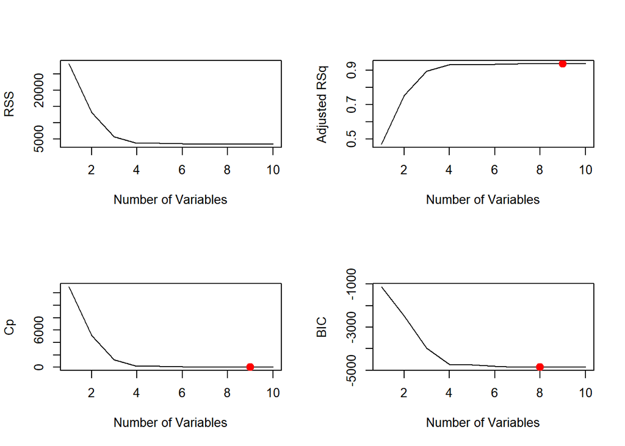

```r
points(which.min(ms0.summary$bic)
,ms0.summary$bic[which.min(ms0.summary$bic)
],col="red",cex=2,pch=20)
```

```r
par(mfrow=c(1,1))
```

- 외부풍속과 작물유무와의 교호작용, 환기창면적이 제거되는 것이 좋아보인다.
- 4개정도의 변수를 포함한 모형도 충분한 경쟁력이 있어 보인다. 이는, 교호작용 중에서는 외부일사량과 환기창면적과의 교호작용만을 포함한 모형이다.
- 환기창면적의 주효과는 제거되는 것이 좋다고 나오지만, 연관된 교호작용들이 의미있으므로 제거하지 않는다.

#### 교차타당검증에 의한 모형 비교

- 지금부터는 train:test=7:3 으로 데이터를 나누어서 몇 개의 후보 모형들의 test RMSE를 계산하여 보겠다. 이 값이 작을수록 예측력이 우수한 모형이라고 볼 수 있다.
- 먼저 데이터를 임의로 train:test=7:3 의 비율로 나눈다. train data는 모형구축 시, test data는 구축된 모형을 평가 시 사용한다.
- 모형에 대한 성능은 test RMSE와 SSE/SST를 바탕으로 실시하며, 두가지 기준 모두 그 값이 작을수록 모형의 예측력이 우수하다고 판단하면 된다.
- $RMSE=\sqrt{{\frac {1}{n} \sum_{i=1}^{n} (y_{i}-\hat{y_{i}})^{2}}}$
- $SSE/SST=\frac {\sum_{i=1}^{n} (y_{i}-\hat{y_{i}})^{2}} {\sum_{i=1}^{n} (y_{i}-\bar{y})^{2}}$

```r
set.seed(5790)
train.index <- sample(1:nrow(plant), round(nrow(plant)*7/10), replace=F)
ex1_train <- plant[train.index,]
ex1_test <- plant[-train.index,]
```

```r
# model1 : 최초로 고려한 모형
m0 <- lm(내부기온~외부기온+외부풍속+외부일사량+환기창면적+작물유무+외부기온*작물유무+외부풍속*작물유무+외부일사량*작물유무+환기창면적*작물유무+환기창면적*외부일사량,data=ex1_train)
y_hat0 <- predict(m0,ex1_test)
RMSE0 <- sqrt(mean((ex1_test$내부기온-y_hat0)^2))
SSE0 <- sum((ex1_test$내부기온-y_hat0)^2)
SST0 <- sum((ex1_test$내부기온-mean(ex1_test$내부기온))^2)
result0 <- data.frame(ex1_test$내부기온, y_hat0, ex1_test$내부기온-y_hat0)
colnames(result0) <- c('y','yhat','y-yhat')
RMSE0 # test RMSE
```

```
## [1] 1.388563
```

```r
SSE0/SST0 # SSE/SST
```

```
## [1] 0.07025184
```

```r
head(result0,12)
```

```
##       y     yhat      y-yhat
## 3  29.1 29.40962 -0.30962110
## 12 35.2 34.31999  0.88000663
## 15 36.8 35.45961  1.34039098
## 17 37.2 36.70646  0.49354348
## 23 41.3 40.30691  0.99308994
## 24 41.6 40.11851  1.48149120
## 37 37.8 37.85748 -0.05748464
## 39 36.3 36.28793  0.01207093
## 43 32.9 32.57513  0.32486796
## 48 28.9 29.16883 -0.26883394
## 51 28.6 29.70117 -1.10116980
## 57 36.2 34.47426  1.72573947
```

```r
# model2 : Adj R^2, Cp, BIC 등의 기준을 바탕으로 선택된 모형 (교호작용 1개 제거)
m0 <- lm(내부기온~외부기온+외부풍속+외부일사량+환기창면적+작물유무+외부기온*작물유무+외부일사량*작물유무+환기창면적*작물유무+환기창면적*외부일사량,data=ex1_train)
y_hat0 <- predict(m0,ex1_test)
RMSE1 <- sqrt(mean((ex1_test$내부기온-y_hat0)^2))
SSE1 <- sum((ex1_test$내부기온-y_hat0)^2)
SST1 <- sum((ex1_test$내부기온-mean(ex1_test$내부기온))^2)
result1 <- data.frame(ex1_test$내부기온, y_hat0, ex1_test$내부기온-y_hat0)
colnames(result1) <- c('y','yhat','y-yhat')
RMSE1 # test RMSE
```

```
## [1] 1.390087
```

```r
SSE1/SST1 # SSE/SST
```

```
## [1] 0.07040613
```

```r
head(result1,12)
```

```
##       y     yhat      y-yhat
## 3  29.1 29.44868 -0.34867595
## 12 35.2 34.23255  0.96745237
## 15 36.8 35.31551  1.48448977
## 17 37.2 36.59035  0.60965235
## 23 41.3 40.27593  1.02407403
## 24 41.6 40.05300  1.54699955
## 37 37.8 37.86814 -0.06813773
## 39 36.3 36.28064  0.01935639
## 43 32.9 32.56307  0.33693087
## 48 28.9 29.18709 -0.28708807
## 51 28.6 29.76995 -1.16994539
## 57 36.2 34.53169  1.66831211
```

```r
# model3 : 모든 주효과와 가장 중요한 교호작용 1가지(환기창면적과 외부일사량)를 포함한 모형
m0 <- lm(내부기온~외부기온+외부풍속+외부일사량+환기창면적+작물유무+환기창면적*외부일사량,data=ex1_train)
y_hat0 <- predict(m0,ex1_test)
RMSE2 <- sqrt(mean((ex1_test$내부기온-y_hat0)^2))
SSE2 <- sum((ex1_test$내부기온-y_hat0)^2)
SST2 <- sum((ex1_test$내부기온-mean(ex1_test$내부기온))^2)
result2 <- data.frame(ex1_test$내부기온, y_hat0, ex1_test$내부기온-y_hat0)
colnames(result2) <- c('y','yhat','y-yhat')
RMSE2 # test RMSE
```

```
## [1] 1.45945
```

```r
SSE2/SST2 # SSE/SST
```

```
## [1] 0.07760778
```

```r
head(result2,12)
```

```
##       y     yhat      y-yhat
## 3  29.1 29.94012 -0.84012236
## 12 35.2 34.90035  0.29964548
## 15 36.8 35.95663  0.84336832
## 17 37.2 37.18376  0.01623787
## 23 41.3 40.54205  0.75794671
## 24 41.6 40.30184  1.29815551
## 37 37.8 37.64294  0.15705564
## 39 36.3 36.03026  0.26974307
## 43 32.9 32.26955  0.63045234
## 48 28.9 28.65851  0.24149018
## 51 28.6 30.07934 -1.47933815
## 57 36.2 34.88778  1.31221728
```

```r
# model4 : 모든 주효과와 가장 중요한 교호작용 2가지(환기창면적과 외부일사량, 작물유무와 외부일사량) 포함한 모형
m0 <- lm(내부기온~외부기온+외부풍속+외부일사량+환기창면적+작물유무+외부일사량*작물유무+환기창면적*외부일사량,data=ex1_train)
y_hat0 <- predict(m0,ex1_test)
RMSE3 <- sqrt(mean((ex1_test$내부기온-y_hat0)^2))
SSE3 <- sum((ex1_test$내부기온-y_hat0)^2)
SST3 <- sum((ex1_test$내부기온-mean(ex1_test$내부기온))^2)
result3 <- data.frame(ex1_test$내부기온, y_hat0, ex1_test$내부기온-y_hat0)
colnames(result3) <- c('y','yhat','y-yhat')
RMSE3 # test RMSE
```

```
## [1] 1.430909
```

```r
SSE3/SST3 # SSE/SST
```

```
## [1] 0.0746021
```

```r
head(result3,12)
```

```
##       y     yhat      y-yhat
## 3  29.1 30.06857 -0.96857433
## 12 35.2 34.81424  0.38575589
## 15 36.8 35.82028  0.97971548
## 17 37.2 37.03301  0.16699353
## 23 41.3 40.38219  0.91781356
## 24 41.6 40.13548  1.46452357
## 37 37.8 37.64648  0.15351621
## 39 36.3 36.07296  0.22703743
## 43 32.9 32.41795  0.48204652
## 48 28.9 28.95004 -0.05004005
## 51 28.6 30.24178 -1.64177822
## 57 36.2 34.90845  1.29154617
```

- 결과적으로 최초로 고려한 모형이 가장 우수하였다.
- 그러나 전체적으로 test RMSE값이 대동소이하다. 이에 단순한 모형을 선택하는 것이 좋아 보인다.
- `:`표시는 교호작용을 의미함.
- model1 : 최초로 고려한 모형
  - 반응변수 : 내부기온
  - 설명변수 : 외부기온, 외부풍속, 외부일사량, 환기창면적, 작물유무, 외부기온:작물유무, 외부풍속:작물유무, 외부일사량:작물유무, 환기창면적:작물유무, 환기창면적:외부일사량
  - RMSE=1.3886, SSE/SST=0.0703
- model2 : Adj R^2, Cp, BIC 등의 기준을 바탕으로 선택된 모형 (교호작용 1개 제거)
  - 반응변수 : 내부기온
  - 설명변수 : 외부기온, 외부풍속, 외부일사량, 환기창면적, 작물유무, 외부기온:작물유무, 외부일사량:작물유무, 환기창면적:작물유무, 환기창면적:외부일사량
  - RMSE=1.3901, SSE/SST=0.0704
- model3 : 모든 주효과와 가장 중요한 교호작용 1가지(환기창면적과 외부일사량)를 포함한 모형
  - 반응변수 : 내부기온
  - 설명변수 : 외부기온, 외부풍속, 외부일사량, 환기창면적, 작물유무, 환기창면적:외부일사량
  - RMSE=1.4595, SSE/SST=0.0776
- model4 : 모든 주효과와 가장 중요한 교호작용 2가지(환기창면적과 외부일사량, 작물유무와 외부일사량) 포함한 모형
  - 반응변수 : 내부기온
  - 설명변수 : 외부기온, 외부풍속, 외부일사량, 환기창면적, 작물유무, 외부일사량:작물유무, 환기창면적:외부일사량
  - RMSE=1.4309, SSE/SST=0.0746

#### 아래는 네 모형에 대한 데이터 전체 적합결과이다.

#### 1. model1

```r
summary(lm(내부기온~외부기온+외부풍속+외부일사량+환기창면적+작물유무+외부기온*작물유무+외부풍속*작물유무+외부일사량*작물유무+환기창면적*작물유무+환기창면적*외부일사량,data=plant) )
```

```
##
## Call:
## lm(formula = 내부기온 ~ 외부기온 + 외부풍속 + 외부일사량 + 환기창면적 +
##     작물유무 + 외부기온 * 작물유무 + 외부풍속 * 작물유무 + 외부일사량 *
##     작물유무 + 환기창면적 * 작물유무 + 환기창면적 * 외부일사량,
##     data = plant)
##
## Residuals:
##     Min      1Q  Median      3Q     Max
## -4.8736 -0.9302  0.0452  0.8905  5.7749
##
## Coefficients:
##                          Estimate Std. Error t value Pr(>|t|)
## (Intercept)             0.1523987  0.5843984   0.261  0.79429
## 외부기온                1.2406328  0.0246941  50.240  < 2e-16 ***
## 외부풍속               -0.9248312  0.0498642 -18.547  < 2e-16 ***
## 외부일사량              0.0221192  0.0005258  42.069  < 2e-16 ***
## 환기창면적             -1.8697315  2.8020594  -0.667  0.50469
## 작물유무yes             3.2287277  0.7008852   4.607 4.38e-06 ***
## 외부기온:작물유무yes   -0.2430229  0.0296411  -8.199 4.59e-16 ***
## 외부풍속:작물유무yes   -0.1277574  0.0689787  -1.852  0.06417 .
## 외부일사량:작물유무yes  0.0043571  0.0004278  10.185  < 2e-16 ***
## 환기창면적:작물유무yes  5.9726761  1.7279318   3.457  0.00056 ***
## 외부일사량:환기창면적  -0.0962399  0.0045077 -21.350  < 2e-16 ***
## ---
## Signif. codes:  0 '***' 0.001 '**' 0.01 '*' 0.05 '.' 0.1 ' ' 1
##
## Residual standard error: 1.381 on 1779 degrees of freedom
## Multiple R-squared:  0.9364, Adjusted R-squared:  0.936
## F-statistic:  2618 on 10 and 1779 DF,  p-value: < 2.2e-16
```

#### 2. model2

```r
summary(lm(내부기온~외부기온+외부풍속+외부일사량+환기창면적+작물유무+외부기온*작물유무+외부일사량*작물유무+환기창면적*작물유무+환기창면적*외부일사량,data=plant) )
```

```
##
## Call:
## lm(formula = 내부기온 ~ 외부기온 + 외부풍속 + 외부일사량 + 환기창면적 +
##     작물유무 + 외부기온 * 작물유무 + 외부일사량 * 작물유무 +
##     환기창면적 * 작물유무 + 환기창면적 * 외부일사량, data = plant)
##
## Residuals:
##     Min      1Q  Median      3Q     Max
## -4.9913 -0.9137  0.0459  0.8953  5.4949
##
## Coefficients:
##                          Estimate Std. Error t value Pr(>|t|)
## (Intercept)             0.1591465  0.5847859   0.272 0.785542
## 외부기온                1.2508186  0.0240904  51.922  < 2e-16 ***
## 외부풍속               -0.9915937  0.0344777 -28.760  < 2e-16 ***
## 외부일사량              0.0220064  0.0005226  42.110  < 2e-16 ***
## 환기창면적             -2.4063050  2.7889447  -0.863 0.388363
## 작물유무yes             3.2973033  0.7003842   4.708  2.7e-06 ***
## 외부기온:작물유무yes   -0.2562908  0.0287820  -8.905  < 2e-16 ***
## 외부일사량:작물유무yes  0.0043566  0.0004281  10.177  < 2e-16 ***
## 환기창면적:작물유무yes  5.8413877  1.7276555   3.381 0.000738 ***
## 외부일사량:환기창면적  -0.0952963  0.0044818 -21.263  < 2e-16 ***
## ---
## Signif. codes:  0 '***' 0.001 '**' 0.01 '*' 0.05 '.' 0.1 ' ' 1
##
## Residual standard error: 1.381 on 1780 degrees of freedom
## Multiple R-squared:  0.9363, Adjusted R-squared:  0.9359
## F-statistic:  2905 on 9 and 1780 DF,  p-value: < 2.2e-16
```

#### 3. model3

```r
summary(lm(내부기온~외부기온+외부풍속+외부일사량+환기창면적+작물유무+환기창면적*외부일사량,data=plant) )
```

```
##
## Call:
## lm(formula = 내부기온 ~ 외부기온 + 외부풍속 + 외부일사량 + 환기창면적 +
##     작물유무 + 환기창면적 * 외부일사량, data = plant)
##
## Residuals:
##    Min     1Q Median     3Q    Max
## -4.721 -0.964  0.104  0.942  5.913
##
## Coefficients:
##                         Estimate Std. Error t value Pr(>|t|)
## (Intercept)            3.1279449  0.4228248   7.398 2.12e-13 ***
## 외부기온               1.0766520  0.0141842  75.905  < 2e-16 ***
## 외부풍속              -0.9407634  0.0356024 -26.424  < 2e-16 ***
## 외부일사량             0.0231782  0.0005316  43.602  < 2e-16 ***
## 환기창면적            -7.2979211  2.3495722  -3.106  0.00193 **
## 작물유무yes            0.0702601  0.1149196   0.611  0.54102
## 외부일사량:환기창면적 -0.0810344  0.0040499 -20.009  < 2e-16 ***
## ---
## Signif. codes:  0 '***' 0.001 '**' 0.01 '*' 0.05 '.' 0.1 ' ' 1
##
## Residual standard error: 1.439 on 1783 degrees of freedom
## Multiple R-squared:  0.9307, Adjusted R-squared:  0.9304
## F-statistic:  3989 on 6 and 1783 DF,  p-value: < 2.2e-16
```

#### 4. model4

```r
summary(lm(내부기온~외부기온+외부풍속+외부일사량+환기창면적+작물유무+외부일사량*작물유무+환기창면적*외부일사량,data=plant) )
```

```
##
## Call:
## lm(formula = 내부기온 ~ 외부기온 + 외부풍속 + 외부일사량 + 환기창면적 +
##     작물유무 + 외부일사량 * 작물유무 + 환기창면적 * 외부일사량,
##     data = plant)
##
## Residuals:
##     Min      1Q  Median      3Q     Max
## -4.9930 -0.9068  0.0563  0.8957  5.8525
##
## Coefficients:
##                          Estimate Std. Error t value Pr(>|t|)
## (Intercept)             3.4297122  0.4178097   8.209 4.24e-16 ***
## 외부기온                1.0710335  0.0139738  76.646  < 2e-16 ***
## 외부풍속               -0.9481707  0.0350400 -27.060  < 2e-16 ***
## 외부일사량              0.0229955  0.0005235  43.925  < 2e-16 ***
## 환기창면적              1.6128971  2.5817721   0.625    0.532
## 작물유무yes            -1.6286794  0.2466609  -6.603 5.30e-11 ***
## 외부일사량:작물유무yes  0.0031882  0.0004114   7.750 1.53e-14 ***
## 외부일사량:환기창면적  -0.0975810  0.0045204 -21.587  < 2e-16 ***
## ---
## Signif. codes:  0 '***' 0.001 '**' 0.01 '*' 0.05 '.' 0.1 ' ' 1
##
## Residual standard error: 1.416 on 1782 degrees of freedom
## Multiple R-squared:  0.9329, Adjusted R-squared:  0.9327
## F-statistic:  3541 on 7 and 1782 DF,  p-value: < 2.2e-16
```

#### 해석

- 전체적으로 비슷한 설명력을 보인다.
- 외부기온은 양의, 외부풍속은 음의 연관성을 내부기온과 가진다. 환기창면적은 커지면 내부기온을 낮추는 효과가 전체적으로 있는 것으로 보인다.
- 작물이 있을 때 내부기온의 수준이 높은 것으로 보인다.